# Modelos Aditivos Generalizados (GAMs)

Samuel Lima & Niege Félix

Os Modelos Aditivos Generalizados são uma extensão dos Modelos Lineares Generalizados (GLMs), permitindo que as relações entre as variáveis independentes e a variável resposta sejam modeladas de forma mais flexível, por meio de funções suavizadas. Mesmo com essa flexibilidade, os GAMs mantêm pressupostos importantes que precisam ser atendidos para garantir a validade dos resultados.

# 1 Pressupostos de um Modelo GAM

## 1.1 Estrutura aditiva

O modelo assume que os efeitos das variáveis explicativas são **aditivos** na escala do preditor linear. Isto é, a relação entre a média da resposta e as covariáveis pode ser expressa como:

$$g(E[Y]) = \beta_0 + s_1(X_1) + s_2(X_2) + \cdots + s_p(X_p)$$

onde $g(\cdot)$ é a função de ligação e $s_j(X_j)$ são funções suavizadas das covariáveis.

## 1.2 Função de ligação e família de distribuição adequadas

Assim como nos GLMs, o GAM assume que os dados seguem uma **família de distribuição da Exponencial** (como normal, Poisson, binomial, gama ou Tweedie) e que há uma **função de ligação** adequada que relaciona a média da resposta com o preditor linear.  
A escolha incorreta da família ou do link pode comprometer o ajuste e a interpretação.

## 1.3 Independência das observações

As observações devem ser **independentes entre si**.  
Quando há dependência temporal, espacial ou hierárquica, o modelo precisa ser ajustado para incluir estruturas de correlação (por exemplo, usando `gamm()` ou `bam()` no pacote `mgcv`).

## 1.4 Relação adequada entre média e variância

A variância da variável resposta deve estar relacionada à sua média conforme a família escolhida.  
Por exemplo: - Poisson: $Var(Y) = E[Y]$ - Binomial: $Var(Y) = E[Y](1 - E[Y])$ - Gama: $Var(Y) = \phi (E[Y])^2$

Se essa relação for incorreta, pode haver **sobredispersão** ou **subdispersão**.

## 1.5 Escolha adequada da suavidade (parâmetro λ)

Os termos suavizados $s_j(X_j)$ possuem um parâmetro de suavização (λ) que controla o grau de flexibilidade da curva: - λ muito alto → curva muito rígida (underfitting); - λ muito baixo → curva muito ondulada (overfitting).

O ajuste ideal é obtido automaticamente pelo método de estimação (ex.: REML, GCV), mas deve ser verificado com diagnósticos (`gam.check()`).

## 1.6 Ausência de concurvity

A **concurvity** é o análogo da **multicolinearidade** nos GAMs.  
Ela ocorre quando um termo suavizado pode ser aproximado por uma combinação de outros termos, prejudicando a estimativa dos efeitos.  
O ideal é que a concurvity seja baixa (valores próximos de 0).

## 1.7 Cobertura adequada dos dados

As funções suavizadas dependem da densidade de dados ao longo do domínio da variável.  
Se houver regiões com poucos dados (especialmente nas bordas), o ajuste pode se tornar instável ou impreciso.

## 1.8 Homoscedasticidade condicional (quando aplicável)

Para famílias contínuas como a **normal**, assume-se variância constante dos erros.  
Para famílias não normais (como Poisson ou gama), essa relação já é modelada internamente, mas deve ser checada com diagnósticos de resíduos.

## 1.9 Comportamento dos resíduos

Os resíduos devem ser **aproximadamente aleatórios**, sem padrões sistemáticos.  
É possível verificar isso com funções como:

```r
library(mgcv)
gam.check(modelo)

library(DHARMa)
res <- simulateResiduals(modelo)
plot(res)
```

# 2 Prática

Carregando pacotes a serem utilizados e importando o banco de dados

```r
library(mgcv) #rodar gam
library(mgcViz)
library(gratia) #visualizar resultados do gam
library(marginaleffects)
library(ggplot2) #plotar
library(dplyr) #manipular dados
library(DHARMa) #avaliação dos residuos
library(performance) #avaliação dos residuos
library(ggeffects)
library(glmmTMB)

dados_gam <- readRDS("../Dados/fisheries.rds")
```

Para exemplificar os Modelos Aditivos Generalizados, vamos utilizar o bando de dados, armazenados no diretório `/Dados` da disciplina. Consiste em um banco de dados simulado que descreve uma típica pescaria de atum no Oceano Atlântico Sul.

Nosso **objetivo** será testar se a pescaria de atum no oceano atlântico é espacialmente concentrada. Nossa **hipótese** é que há um maior concentração nos trópicos devido a maior produtividade e, consequentemente, maior concentração de recursos para os atuns.

## 2.1 Análise exploratória

```r
head(dados_gam)
```

```
##    Ano Mes N_anzol Barco Pais      Long         Lat Thunnus_albacares
## 1 2003   1    1050  V201    B -33.26132 -27.8554293                 4
## 2 2003   1    1050  V201    B -38.77901   0.3989468                27
## 3 2003   1    1050  V201    B -38.06032 -15.6954441                 5
## 5 2003   1    1050  V201    B -35.78174  -1.9970646                55
## 6 2003   1    1050  V201    B -36.91482 -19.6665970                 7
## 7 2003   1     980  V122    B -27.54282   0.1103499                11
##   Thunnus_atlanticus Katsuwonus_pelamis Xiphias_gladius Istiophorus_albicans
## 1                  0                  5               0                    3
## 2                 32                  0               0                    0
## 3                  0                  7               0                    0
## 5                  0                  0               0                   11
## 6                  4                  5               0                    0
## 7                 18                  0               0                    5
##   Tetrapturus_albidus Makaira_nigricans Ruvettus_pretiosus Coryphaena_hippurus
```

[output cut: 27 more lines]

```r
str(dados_gam)
```

```
## 'data.frame':    476 obs. of  33 variables:
##  $ Ano                     : int  2003 2003 2003 2003 2003 2003 2003 2003 2003 2003 ...
##  $ Mes                     : int  1 1 1 1 1 1 1 1 1 1 ...
##  $ N_anzol                 : int  1050 1050 1050 1050 1050 980 955 960 960 1052 ...
##  $ Barco                   : chr  "V201" "V201" "V201" "V201" ...
##  $ Pais                    : Factor w/ 3 levels "A","B","C": 2 2 2 2 2 2 2 2 2 2 ...
##  $ Long                    : num  -33.3 -38.8 -38.1 -35.8 -36.9 ...
##  $ Lat                     : num  -27.855 0.399 -15.695 -1.997 -19.667 ...
##  $ Thunnus_albacares       : num  4 27 5 55 7 11 29 58 6 14 ...
##  $ Thunnus_atlanticus      : num  0 32 0 0 4 18 0 0 4 13 ...
##  $ Katsuwonus_pelamis      : num  5 0 7 0 5 0 36 0 0 7 ...
##  $ Xiphias_gladius         : num  0 0 0 0 0 0 0 0 2 0 ...
##  $ Istiophorus_albicans    : num  3 0 0 11 0 5 0 12 3 0 ...
##  $ Tetrapturus_albidus     : num  3 6 0 0 2 7 0 0 2 0 ...
##  $ Makaira_nigricans       : num  0 0 0 0 0 0 0 0 0 0 ...
```

[output cut: 19 more lines]

```r
#Abundância total das espécies alvo (atum)
dados_gam %>%
  dplyr::select(Thunnus_albacares,Thunnus_atlanticus,
                Katsuwonus_pelamis,Prionace_glauca) %>%
  colSums(.)
```

```
##  Thunnus_albacares Thunnus_atlanticus Katsuwonus_pelamis    Prionace_glauca
##               6009               4504               3944               4846
```

A partir de agora vamos trabalhar apenas com a espécie de atum com maior abundância (`Thunnus_albacares`)

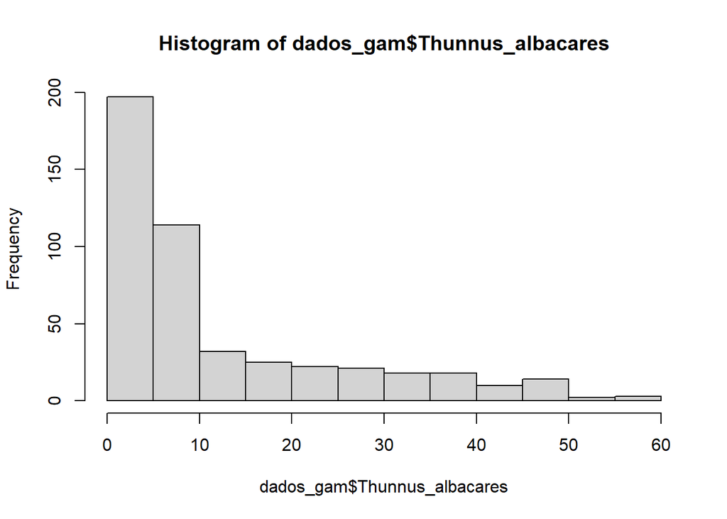

```r
hist(dados_gam$Thunnus_albacares)
```

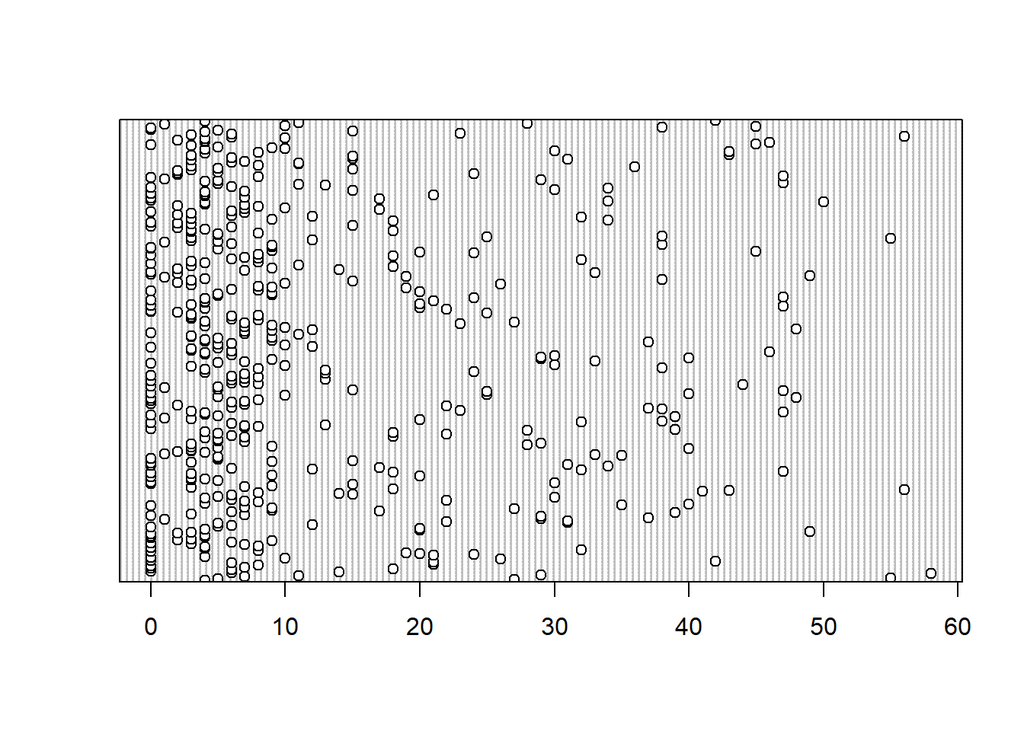

```r
dotchart(dados_gam$Thunnus_albacares)
```

```r
ifelse(is.na(dados_gam$Thunnus_albacares) == TRUE,1, 0) %>% sum()
```

```
## [1] 0
```

Distribuição típica de uma variável de contagem, não há outliers aparentes, nem NAs.

Como vamos trabalhar apenas com latitude e longitude, não precisamos ajustar o tipo das variáveis.

### 2.1.1 Observando correlações

```r
tmp <- dados_gam[, c("Thunnus_albacares", "Lat", "Long")]
cor(tmp,method = "pearson")
```

```
##                   Thunnus_albacares         Lat        Long
## Thunnus_albacares        1.00000000  0.57424986 -0.07420615
## Lat                      0.57424986  1.00000000 -0.08463976
## Long                    -0.07420615 -0.08463976  1.00000000
```

```r
cor(tmp,method = "spearman") #para dados com distribuição não normal
```

```
##                   Thunnus_albacares         Lat        Long
## Thunnus_albacares        1.00000000  0.54406881 -0.06606919
## Lat                      0.54406881  1.00000000 -0.05505784
## Long                    -0.06606919 -0.05505784  1.00000000
```

### 2.1.2 Observando tendências

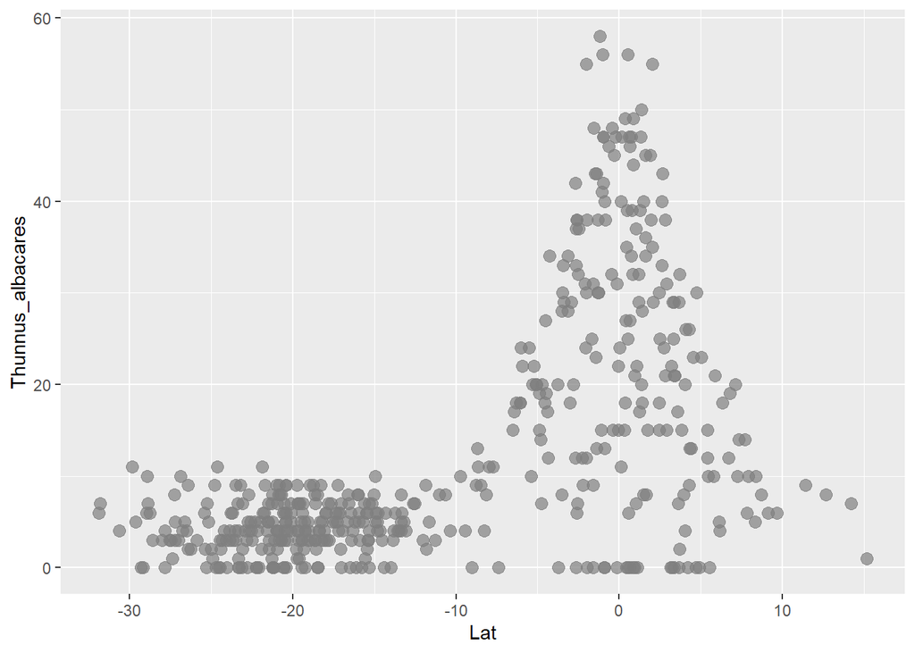

```r
ggplot(dados_gam,aes(x=Lat,y=Thunnus_albacares))+
  geom_point(size = 3, col = 'gray50',alpha = 0.7)
```

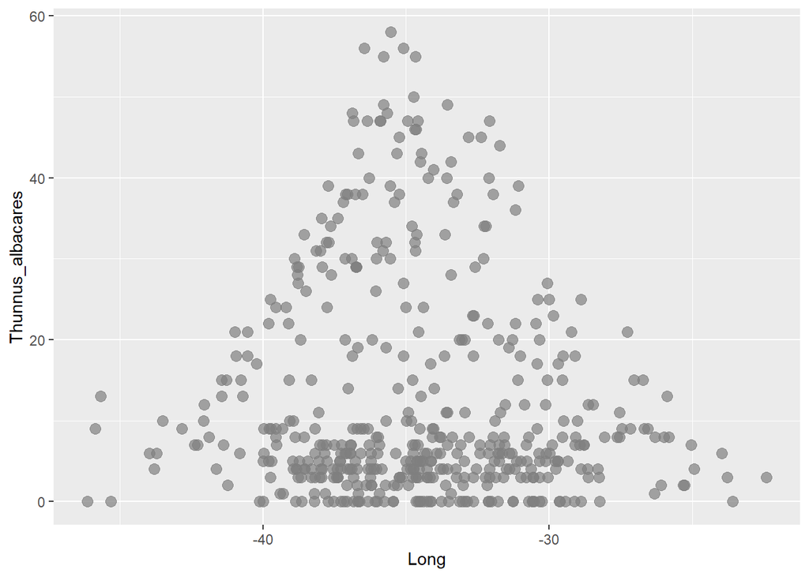

```r
ggplot(dados_gam,aes(x=Long,y=Thunnus_albacares))+
  geom_point(size = 3, col = 'gray50',alpha = 0.7)
```

Claras relações não lineares. Com picos de abundância na latitude 0 e na longitude -35

## 2.2 Modelando os dados

```r
## Vamos iniciar com modelos lineares polinomiais e ir até ao GAM

## Modelo com termo quadrático
mod_glm2 <- glmmTMB(Thunnus_albacares ~ poly(Lat, 2)+poly(Long, 2),
              data = dados_gam,
              family = poisson)


## Modelo com termo cúbico
mod_glm3 <- glmmTMB(Thunnus_albacares ~ poly(Lat, 3)+poly(Long, 3),
              data = dados_gam,
              family = poisson)


## Modelo com termo à quarta
mod_glm4 <- glmmTMB(Thunnus_albacares ~ poly(Lat, 4)+poly(Long, 4),
              data = dados_gam,
              family = poisson)

AIC(mod_glm2, mod_glm3,mod_glm4)
```

```
##          df      AIC
## mod_glm2  5 4634.551
## mod_glm3  7 3951.064
## mod_glm4  9 3901.167
```

Quanto maior o termo, melhor foi o ajuste do modelo.

Vamos verificar como está o ajuste dos resíduos do melhor modelo até o momento

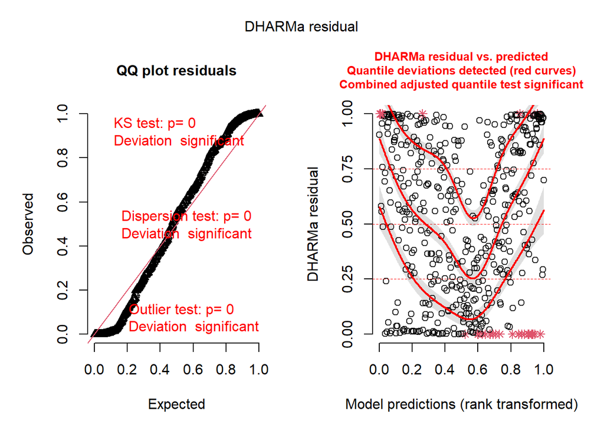

```r
simres<-simulateResiduals(mod_glm4, n=1000, plot=T)
```

```r
check_overdispersion(simres)
```

```
## # Overdispersion test
##
##  dispersion ratio =   4.544
##           p-value = < 0.001
```

```r
check_zeroinflation(simres)
```

```
## # Check for zero-inflation
##
##    Observed zeros: 56
##   Predicted zeros: 8
##             Ratio: 0.15
```

Péssimo ajuste dos resíduos, sobredispersão e subajuste os zeros. Observando graficamente:

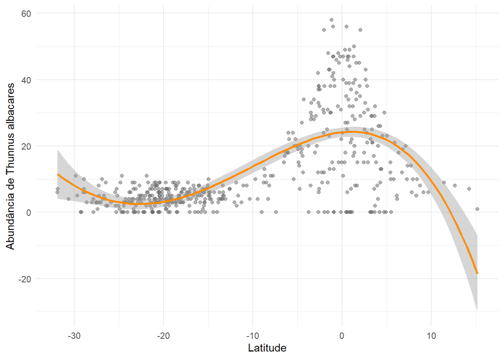

```r
ggplot(dados_gam, aes(x=Lat, y=Thunnus_albacares)) +
  geom_point(alpha = 0.5, col="gray40") +
  geom_smooth(method = "glm", formula = y~poly(x,4),
              col = "darkorange", se = T) +
  labs(y = "Abundância de Thunnus albacares", x = "Latitude") +
  theme_minimal()
```

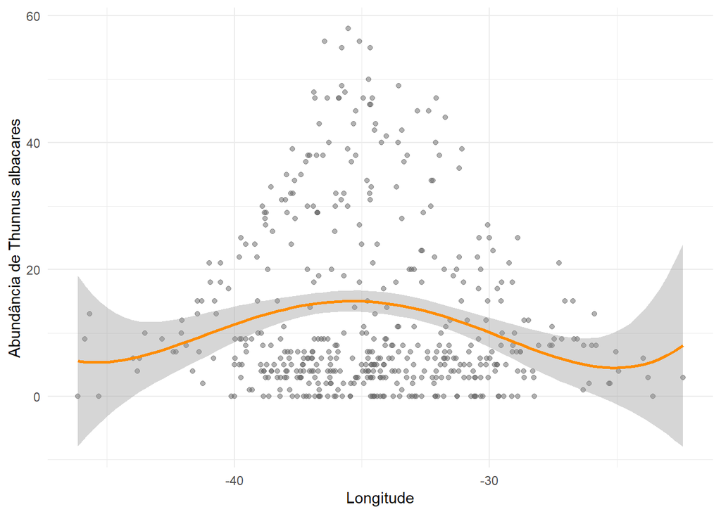

```r
ggplot(dados_gam, aes(x=Long, y=Thunnus_albacares)) +
  geom_point(alpha = 0.5, col="gray40") +
  geom_smooth(method = "glm", formula = y~poly(x,4),
              col = "darkorange", se = T) +
  labs(y = "Abundância de Thunnus albacares", x = "Longitude") +
  theme_minimal()
```

> Vamos testar com outras distribuições e o GAM

```r
#Binomial negativa
mod_glm5 <- glmmTMB(Thunnus_albacares ~ poly(Lat, 4)+poly(Long, 4),
                data = dados_gam,
                family = nbinom2(link = "log"))

#Binomial negativa truncada
mod_glm5b <- glmmTMB(Thunnus_albacares ~ poly(Lat, 4)+poly(Long, 4),
                     ziformula = ~Lat+Long,
                     data = dados_gam,
                     family = truncated_nbinom2(link = "log"))

#GAM com distriubuição inflada por zero
#aditivo
mod_gam1 <- gam(Thunnus_albacares ~ s(Long)+s(Lat),
                data = dados_gam,
                family = "ziP")

#interativo
mod_gam2 <- gam(Thunnus_albacares ~ s(Long,Lat),
                data = dados_gam,
                family = "ziP")

AIC(mod_glm5, mod_glm5b, mod_gam1, mod_gam2)
```

```
##                 df      AIC
## mod_glm5  10.00000 3042.596
## mod_glm5b 13.00000 2754.830
## mod_gam1  19.70816 2636.402
## mod_gam2  26.99339 2517.797
```

O GAM interativo apresentou o menor AIC

## 2.3 Verificando resíduos do melhor modelo

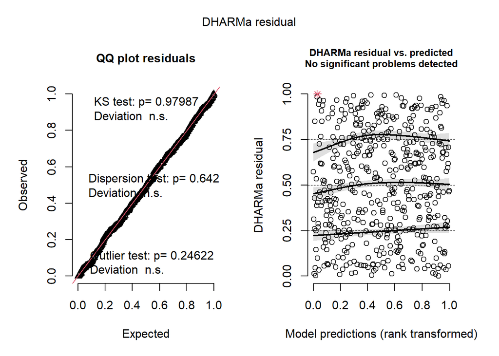

```r
simres2<-simulateResiduals(mod_gam2, n=1000,plot = T)
```

```r
check_overdispersion(simres2)
```

```
## # Overdispersion test
##
##  dispersion ratio = 0.980
##           p-value = 0.642
```

```r
check_zeroinflation(simres2)
```

```
## # Check for zero-inflation
##
##    Observed zeros: 56
##   Predicted zeros: 56
##             Ratio: 1.00
```

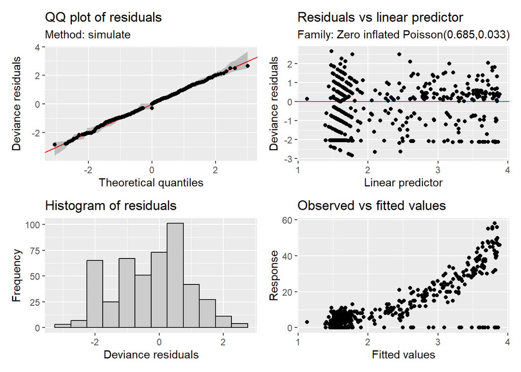

```r
#Bom ajuste, sem sobredispersão e inflação de zeros.


gratia::appraise(mod_gam2,
                 method = 'simulate',
                 seed = 123)
```

> Agora sim, tudo certo!

## 2.4 Resultados

```r
summary(mod_gam2)
```

```
##
## Family: Zero inflated Poisson(0.685,0.033)
## Link function: identity
##
## Formula:
## Thunnus_albacares ~ s(Long, Lat)
##
## Parametric coefficients:
##             Estimate Std. Error z value Pr(>|z|)
## (Intercept)  2.28705    0.01801     127   <2e-16 ***
## ---
## Signif. codes:  0 '***' 0.001 '**' 0.01 '*' 0.05 '.' 0.1 ' ' 1
##
## Approximate significance of smooth terms:
##               edf Ref.df Chi.sq p-value
## s(Long,Lat) 23.81  27.33   3839  <2e-16 ***
## ---
## Signif. codes:  0 '***' 0.001 '**' 0.01 '*' 0.05 '.' 0.1 ' ' 1
##
## Deviance explained = 86.6%
## -REML = 1282.9  Scale est. = 1         n = 476
```

Diferentemente dos GLMs, nossos coeficientes não estão junto do intercepto. Isso porque aqui temos diversos coeficientes para uma única função suave. Eles são determinados pelo número de nós determinado pela função suave. Podemos extrai-los com a seguinte função:

```r
coef(mod_gam2)
```

```
##    (Intercept)  s(Long,Lat).1  s(Long,Lat).2  s(Long,Lat).3  s(Long,Lat).4
##     2.28704893     1.43063322     0.18713672    -1.01656755    -0.46044631
##  s(Long,Lat).5  s(Long,Lat).6  s(Long,Lat).7  s(Long,Lat).8  s(Long,Lat).9
##     0.73674275    -0.43737042    -0.36639391    -0.33694825    -0.03778837
## s(Long,Lat).10 s(Long,Lat).11 s(Long,Lat).12 s(Long,Lat).13 s(Long,Lat).14
##    -0.64610253     0.08240183    -0.09027388     0.70154688    -0.49345038
## s(Long,Lat).15 s(Long,Lat).16 s(Long,Lat).17 s(Long,Lat).18 s(Long,Lat).19
##     0.49464400    -0.15809203     0.44379521    -0.49934636     0.57814537
## s(Long,Lat).20 s(Long,Lat).21 s(Long,Lat).22 s(Long,Lat).23 s(Long,Lat).24
##     0.35697107    -0.48528902     0.62478537     0.34055266    -0.69791642
## s(Long,Lat).25 s(Long,Lat).26 s(Long,Lat).27 s(Long,Lat).28 s(Long,Lat).29
##    -0.02237160    -0.50409883     3.60868076    -0.06587006    -0.36852802
```

O modelo utilizou 29 funções básicas.

Visualizando os resultados:

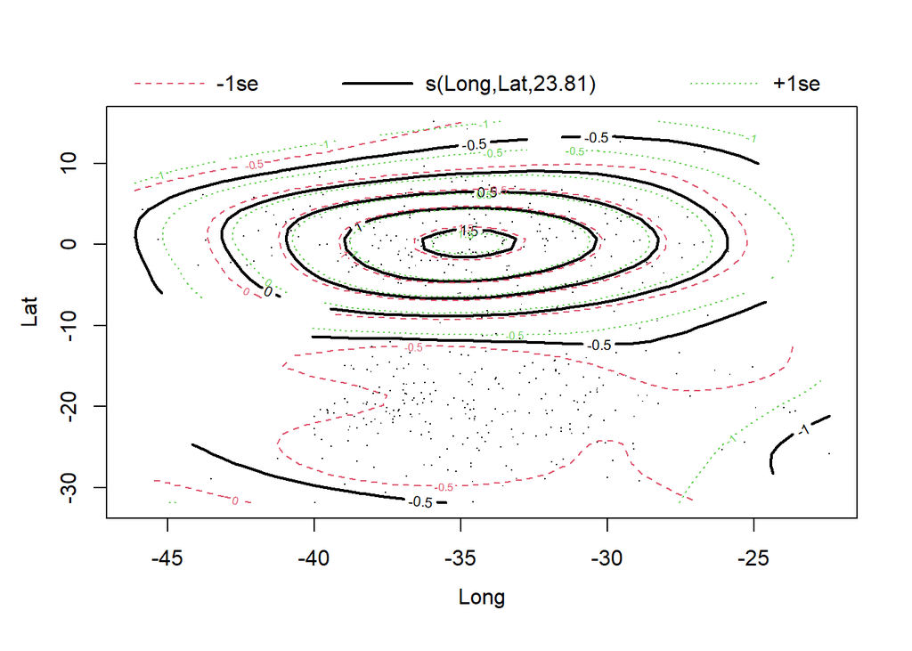

```r
plot(mod_gam2)
```

Esse gráfico mostra a relação das variáveis preditoras com o efeito de suavização. O eixo da suavização é centrado em 0 (média dos dados da variável y). Valores acima representam efeito positivo e abaixo, negativo. Porém, como se trata aqui de um efeito interativo, vamos observar de outra maneira para facilitar a interpretação…

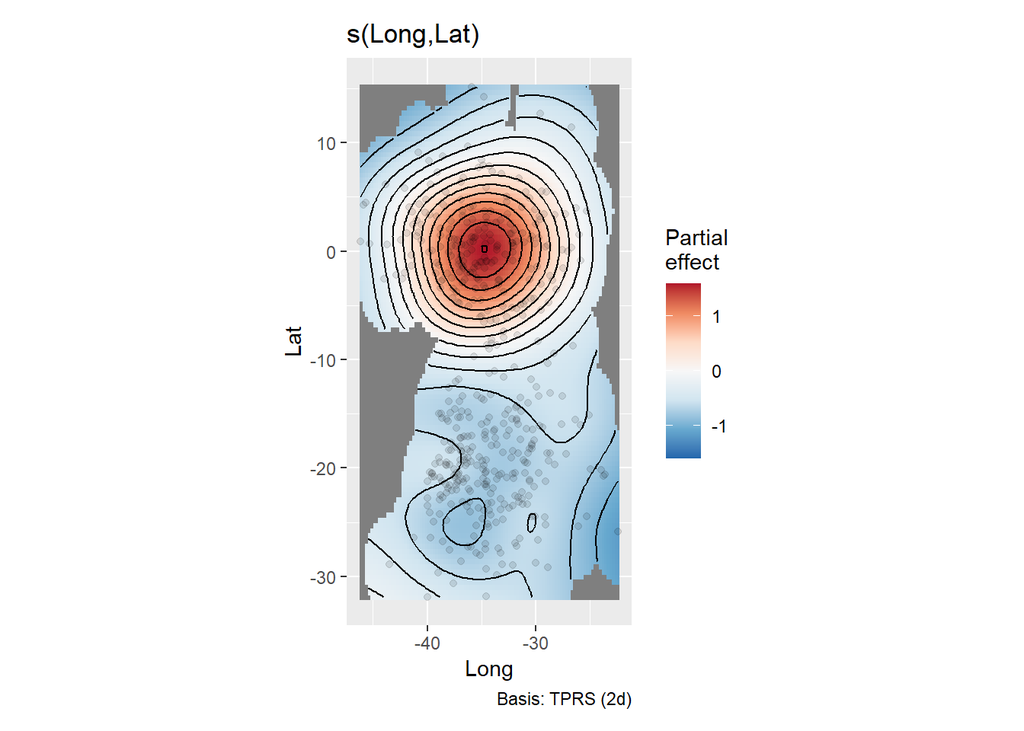

```r
gratia::draw(mod_gam2)
```

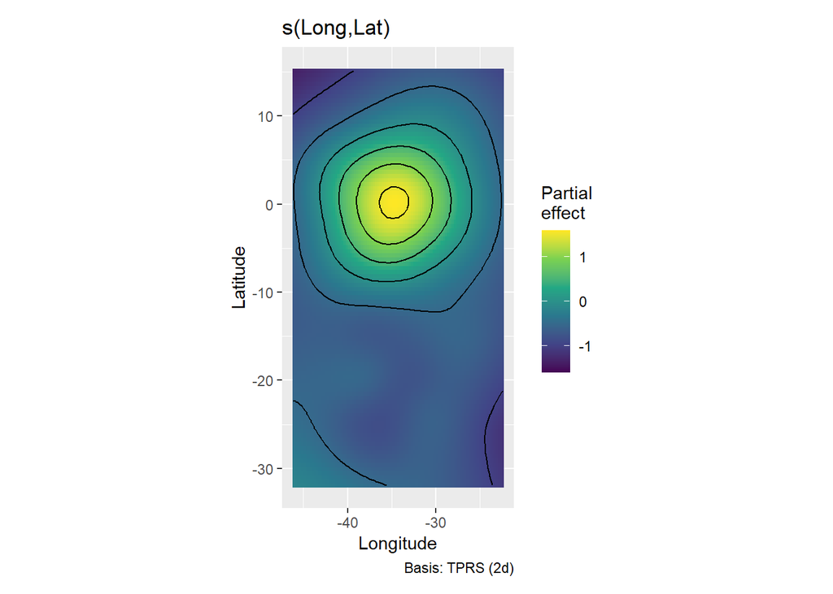

```r
#Ou ainda:
sm <- smooth_estimates(mod_gam2, select = c("s(Long,Lat)"))
draw(sm) +
  scale_fill_viridis_c(option = "D") +
  labs(x = "Longitude",
       y = "Latitude")
```

Efeito parcial de cada variável com a unidade original da variável resposta:

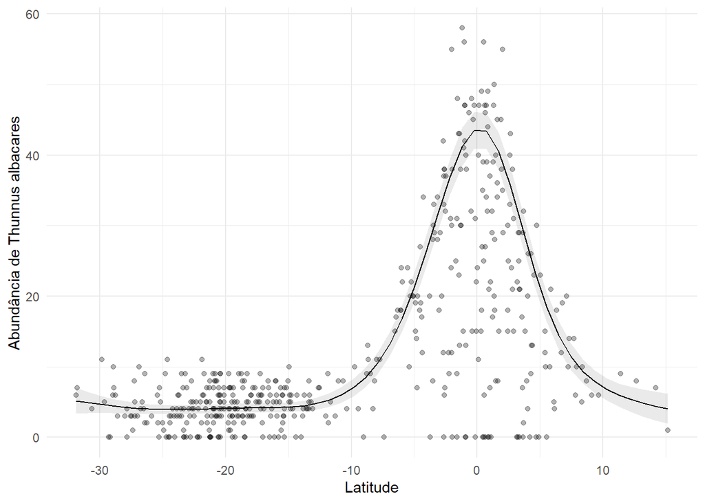

```r
plot_predictions(mod_gam2, condition = "Lat",points = 0.3)+
  labs(y = "Abundância de Thunnus albacares", x = "Latitude") +
  theme_minimal()
```

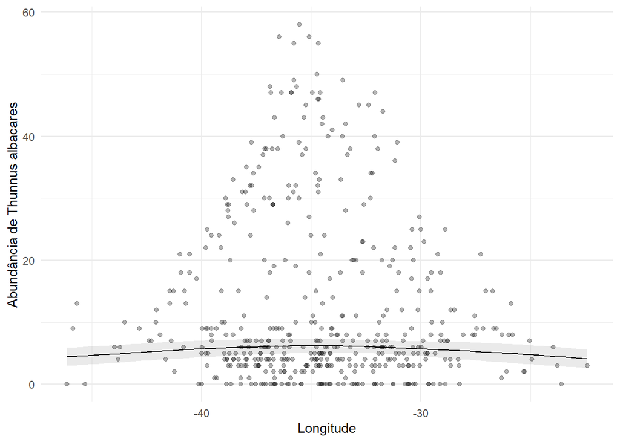

```r
plot_predictions(mod_gam2, condition = "Long",points = 0.3)+
  labs(y = "Abundância de Thunnus albacares", x = "Longitude") +
  theme_minimal()
```

Olhando o efeito unico da longitude, podemos ver que ainda não há um bom ajuste. Provavelmente porque nosso modelo não contém as variáveis ambientais, que devem explicar boa parte da variação restante.

Entretanto, nossa hipótese inicial foi corroborada. Há uma maior abundância de atum nas menores latitudes, especialmente nos trópicos. Ainda pudemos ver que isso acontece principalmente na região mais central longitudinalmente da área de estudo.